[figure not shown]

# General guidance

**Adding comments to your code**

Hard to overstate the importance of this.  
One of the big plus points of doing things in R is **reproducibility**  
If we don’t comment our code well, others won’t be able to reproduce it, because they won’t understand it (and the same will go for us after a few months, or a few weeks if I’m speaking for myself)

**Security**

We need to be careful about installing R packages.  
There may be malicious packages out there that could damage our network.  
So we need to stick to the popular packages, and we shouldn’t install anything unusual without checking first that others have used it and it’s harmless.

**Version control**

In time, we may adopt Git, which is an advanced form of version control used by programmers.  
Part of the rationale for something like Git is that it’s easy to mess up your code and then not be able to fix it, and then you find your previous version is missing a lot of progress you had made since. Git enables you to roll back to different steps along the way.  
This is not dissimilar to standard OAT version control, except that we don’t tend to save things that often.  
So, in the meantime, it is suggested that we save R scripts twice a day, keeping the middle of the filename the same but changing the date, and then adding ‘am’ or ‘pm’ to the end of the filename.  
Standard ‘v0a’ and ‘v1a’ notation can be used alongside this.

**When you get stuck**

This is definitely going to happen, especially when new to R.  
Here are some tips:

- as you would do with SQL, start commenting out bits of your script until it works again. In this way you will hopefully be able to isolate the problem.
- if it’s a big script, especially an RMarkdown document (Rmd), it can be helpful to produce a ‘minimal working example’ in a standard R script or a smaller Rmd. This is where you produce the smallest and simplest possible version of your problem, potentially with dummy data, making it as easy as possible to diagnose the fault. When posting on a forum or sending a script to a colleague (or a consultancy) for support, a minimal working example could make it much easier for them to help you with than your full script.
- Restart RStudio using Session > Restart R or ctrl + shift + F10. Occasionally this works, classic IT solution!  
  We all need to find the balance between always trying to solve problems ourselves - this brings satisfaction and learning development but can take too long - and always going straight to a colleague for help - which is quicker but can hinder learning.

**Better to comment than delete**

As with SQL, it can be better to comment bits out that don’t work, rather than deleting them, because:

- you can then easily bring those bits back in later if required
- you can add a comment to say why it doesn’t work - this can be helpful for yourself or others at a later date to remember which avenues have already been tried when trying to fix a problem.

**Add hyperlinks to reference the fixes you googled**

If you find a good source of information online, put a hyperlink in your code for further reference later. For example,

```r
# code below was taken from following page
# https://rmarkdown.rstudio.com/flexdashboard/
```

# Installing packages

Within RStudio, go the ‘Packages’ tab in the bottom-right window.  
Click ‘Install’ and then type in the package you are looking for.  
Once the package is installed, you need to use library() to load it. For example, having installed ggplot2, you load it by running **library(ggplot2)**

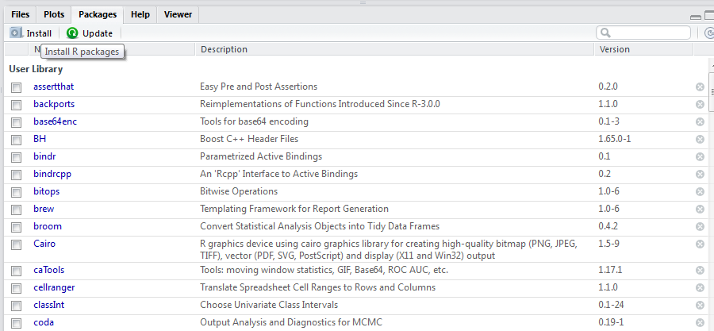

# Linking to SQL tables

# Publishing issues

A common thing to go wrong is leaving in links to the P drive.  
Once you publish to the shinyapps.io service, a package of files is created, and any links (e.g. to open a csv) need to be relative:

```r
read.csv("file_name")
```

rather than absolute:

```r
read.csv("P:\\ .... \ ... \file_name")
```

This [page](https://support.rstudio.com/hc/en-us/articles/115004341427-Why-can-t-I-publish-my-content-to-RStudio-Connect-from-the-IDE-after-I-ve-established-a-connection-) describes how to re-establish the connection to shinyapps.io if the below error message comes up.

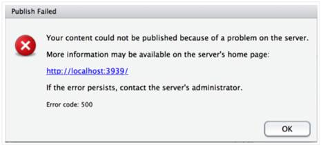

# Bar/line chart

The below chart is a standard format used by OAT.

Next to the chart is the code used, with comments to show what each bit is doing.

### LA / HB chart

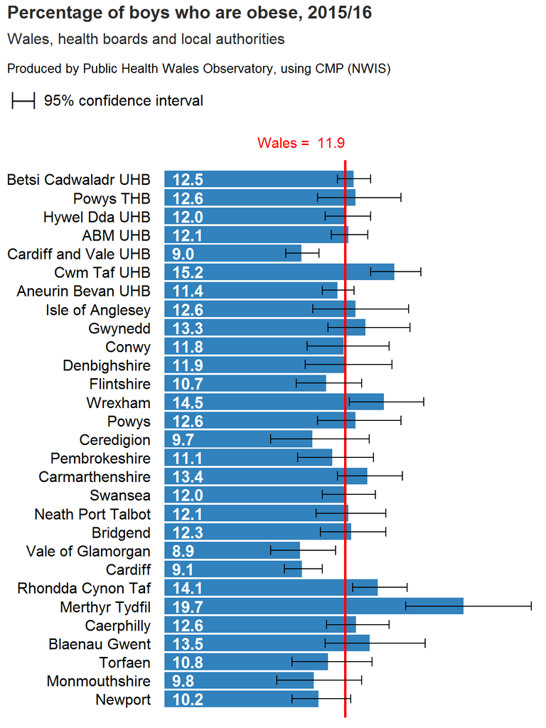

### Code used to produce the LA / HB chart

```r
# Produce data for chart

# create data for bars
chartdata <- subset(cmp_la_hb, sex=="boys" & weight_names=="Obese")

# put areas in right order
chartdata$area <- factor(chartdata$area, levels = rev(chartdata$area[order(chartdata$area_order)]))

# Create data for Wales line
chartdata_Wales <-subset(cmp_wales, sex=="boys" & weight_names=="Obese")

# Create title
title <- textGrob(paste("Percentage of boys who are obese, 2015/16", sep=""),
           gp=gpar(fontsize=16, fontface = "bold", col="#2b2b2b"),
           x=unit(2, "mm"), just=c("left", "bottom"))

# Create subtitle
subtitle <- textGrob("Wales, health boards and local authorities",
           gp=gpar(fontsize=14, col="#2b2b2b"),
           x=unit(2, "mm"), just=c("left", "bottom"))

# Create 'Produced by'
source <-  textGrob("Produced by Public Health Wales Observatory, using CMP (NWIS)",  gp=gpar(fontsize=12, col="black"),
           x=unit(2, "mm"), just=c("left", "bottom"))


# Making confidence interval symbol using Unicode box drawing symbols
# https://en.wikipedia.org/wiki/Unicode_input
# Microsoft Windows has provided a Unicode version of the Character Map program (find it by hitting Win+R then type charmap then hit Enter)
# https://support.rstudio.com/hc/en-us/articles/200532197-Character-Encoding
# "If in doubt, save with encoding UTF-8"
ci_symbol <- textGrob("\U251C\U2500\U2524 95% confidence interval",
           gp=gpar(fontsize=12, col="black"),
           x=unit(2, "mm"), just=c("left", "bottom"))

# Make the chart

# Main ggplot command - x axis ends up being vertical, and y horizontal,
# because of the chart axis being flipped
chart <- ggplot(chartdata, aes(x=area, y=percent)) +

  # add the bars
  geom_col(fill = '#3182BD') +

  # flip horizontal (default would be vertical bars)
  coord_flip() +

  # reduce gap between axis and area labels (0.02 looks OK)
  scale_y_continuous(expand = c(0.02,0)) +

  # add Wales line
  geom_segment(chartdata_Wales, mapping=aes(x=0,xend=30,y=percent,yend=percent), colour="Red", size = 1) +

  # add Wales line label
  geom_text(data=chartdata_Wales, aes(label=paste("Wales = ",sprintf("%.1f",percent)), x=31, y = percent), color =  "Red", hjust = 1, size = 5) +

  # expand limits of x axis to fit in Wales line label
  expand_limits(x=c(0,32)) +

  # add error bars
  geom_errorbar(aes(ymin=lcl, ymax=ucl, width = 0.5)) +

  # add data labels
  geom_text(aes(y=0.5, label = sprintf("%.1f",percent)), colour = "White", size = 4.5, fontface = "bold", hjust = 0) +

  # styling - remove unnecessary elements and size axis labels
  # experiment with commenting each line in and out to see what they do
      theme(axis.line.y = element_blank(),
            panel.background = element_blank(),
            axis.ticks.y=element_blank(),
            axis.text.y=element_text(size=12, colour = "black"),
            axis.ticks.x=element_blank(),
            axis.text.x = element_blank(),
            axis.title.x = element_blank(),
            axis.title.y = element_blank())


grid.arrange(
  title
  , subtitle
  , source
  , ci_symbol
  , chart
  , heights=c(0.05, 0.02, 0.06, 0.03, 0.84)
)
```